# SmitrajRaut_Personal_Loan_Full_Code_Notebook

#### **Question 17:** What are the relationships between Predictor and Target?

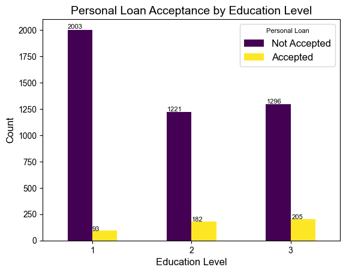

```python
# Create a crosstab to count the occurrences of each Personal_Loan status within
# each Education level.
education_loan_crosstab = pd.crosstab(personal_loan_df['Education'], personal_loan_df['Personal_Loan'])

# Plot the bar plot.
ax = education_loan_crosstab.plot(kind='bar', colormap='viridis')
plt.title('Personal Loan Acceptance by Education Level')
plt.xlabel('Education Level')
plt.ylabel('Count')
plt.legend(title='Personal Loan', labels=['Not Accepted', 'Accepted'])
plt.xticks(rotation=0)

# Add totals on top of the bars.
for p in ax.patches:
    ax.annotate(str(p.get_height()), (p.get_x() * 1.005, p.get_height() * 1.005))

plt.show()
```

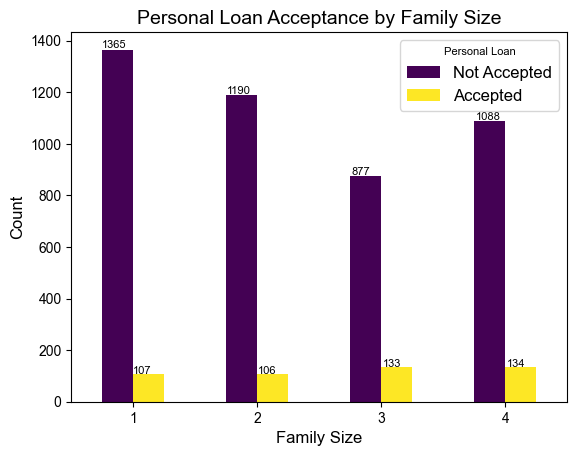

```python
# Create a crosstab to count the occurrences of each Personal_Loan status for family size.
family_crosstab = pd.crosstab(personal_loan_df['Family'], personal_loan_df['Personal_Loan'])

# Plot the bar plot.
ax = family_crosstab.plot(kind='bar', colormap='viridis')
plt.title('Personal Loan Acceptance by Family Size')
plt.xlabel('Family Size')
plt.ylabel('Count')
plt.legend(title='Personal Loan', labels=['Not Accepted', 'Accepted'])
plt.xticks(rotation=0)

# Add totals on top of the bars.
for p in ax.patches:
    ax.annotate(str(p.get_height()), (p.get_x() * 1.005, p.get_height() * 1.005))

plt.show()
```

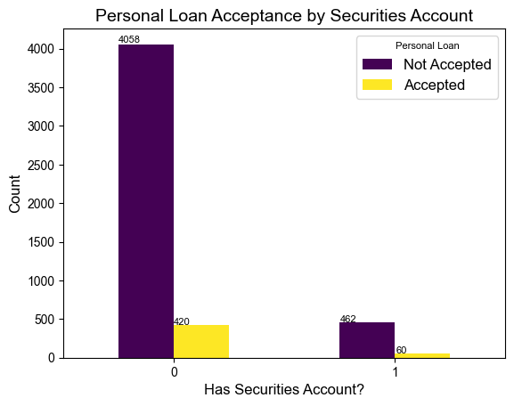

```python
# Create a crosstab to count the occurrences of each Personal_Loan status for Security Account holders.
sec_acct_crosstab = pd.crosstab(personal_loan_df['Securities_Account'], personal_loan_df['Personal_Loan'])

# Plot the bar plot.
ax = sec_acct_crosstab.plot(kind='bar', colormap='viridis')
plt.title('Personal Loan Acceptance by Securities Account')
plt.xlabel('Has Securities Account?')
plt.ylabel('Count')
plt.legend(title='Personal Loan', labels=['Not Accepted', 'Accepted'])
plt.xticks(rotation=0)

# Add totals on top of the bars.
for p in ax.patches:
    ax.annotate(str(p.get_height()), (p.get_x() * 1.005, p.get_height() * 1.005))

plt.show()
```

```python
# Create a crosstab to count the occurrences of each Personal_Loan status for ZIP codes.
zipcode_crosstab = pd.crosstab(personal_loan_df['ZIPCode'], personal_loan_df['Personal_Loan'])

# Add a 'Total' column and row.
zipcode_crosstab['Total'] = zipcode_crosstab.sum(axis=1)

# Sort the table by the 'Total' column in descending order.
zipcode_crosstab = zipcode_crosstab.sort_values(by='Total', ascending=False)

# Add the 'Total' row after sorting.
zipcode_crosstab.loc['Total'] = zipcode_crosstab.sum()

print(zipcode_crosstab)
```

```
Personal_Loan     0    1  Total
ZIPCode
94720           150   19    169
94305           114   13    127
95616           110    6    116
90095            63    8     71
93106            53    4     57
...             ...  ...    ...
94965             1    0      1
90068             1    0      1
94970             1    0      1
91024             1    0      1
Total          4520  480   5000

[468 rows x 3 columns]
```

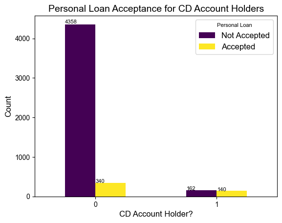

```python
# Create a crosstab to count the occurrences of each Personal_Loan status for CD Account holders.
cd_acct_crosstab = pd.crosstab(personal_loan_df['CD_Account'], personal_loan_df['Personal_Loan'])

# Plot the bar plot.
ax = cd_acct_crosstab.plot(kind='bar', colormap='viridis')
plt.title('Personal Loan Acceptance for CD Account Holders')
plt.xlabel('CD Account Holder?')
plt.ylabel('Count')
plt.legend(title='Personal Loan', labels=['Not Accepted', 'Accepted'])
plt.xticks(rotation=0)

# Add totals on top of the bars.
for p in ax.patches:
    ax.annotate(str(p.get_height()), (p.get_x() * 1.005, p.get_height() * 1.005))

plt.show()
```

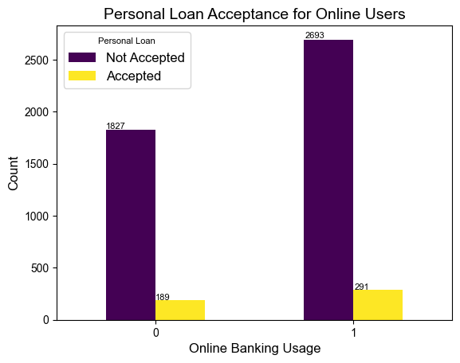

```python
# Create a crosstab to count the occurrences of each Personal_Loan status for Online users.
cd_acct_crosstab = pd.crosstab(personal_loan_df['Online'], personal_loan_df['Personal_Loan'])

# Plot the bar plot.
ax = cd_acct_crosstab.plot(kind='bar', colormap='viridis')
plt.title('Personal Loan Acceptance for Online Users')
plt.xlabel('Online Banking Usage')
plt.ylabel('Count')
plt.legend(title='Personal Loan', labels=['Not Accepted', 'Accepted'])
plt.xticks(rotation=0)

# Add totals on top of the bars.
for p in ax.patches:
    ax.annotate(str(p.get_height()), (p.get_x() * 1.005, p.get_height() * 1.005))

plt.show()
```

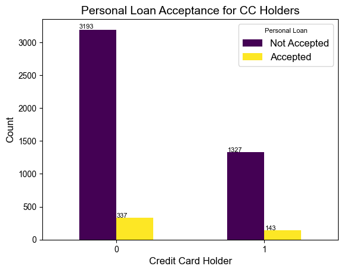

```python
# Create a crosstab to count the occurrences of each Personal_Loan status for CC Holders.
cc_crosstab = pd.crosstab(personal_loan_df['CreditCard'], personal_loan_df['Personal_Loan'])

# Plot the bar plot.
ax = cc_crosstab.plot(kind='bar', colormap='viridis')
plt.title('Personal Loan Acceptance for CC Holders')
plt.xlabel('Credit Card Holder')
plt.ylabel('Count')
plt.legend(title='Personal Loan', labels=['Not Accepted', 'Accepted'])
plt.xticks(rotation=0)

# Add totals on top of the bars.
for p in ax.patches:
    ax.annotate(str(p.get_height()), (p.get_x() * 1.005, p.get_height() * 1.005))

plt.show()
```

[figure not shown]

```python
# Customize font properties for better readability.
plt.rcParams.update({
    'font.size': 8,
})

# Create a crosstab to count the occurrences of each Personal_Loan status for Average CC spending.
cc_crosstab = pd.crosstab(personal_loan_df['CCAvg'], personal_loan_df['Personal_Loan'])

# Reset the index to convert the crosstab into a DataFrame suitable for seaborn.
cc_crosstab = cc_crosstab.reset_index()

# Melt the DataFrame to long format for seaborn.
cc_crosstab_melted = cc_crosstab.melt(id_vars='CCAvg', value_vars=[0, 1], var_name='Personal_Loan', value_name='Count')

# Plot the histogram.
ax = sns.histplot(data=cc_crosstab_melted, x='CCAvg', hue='Personal_Loan', weights='Count', multiple='stack', palette='viridis')
plt.title('Personal Loan Acceptance for CC Average Spending')
plt.xlabel('Average CC Spending')
plt.ylabel('Count')
plt.legend(title='Personal Loan', labels=['Not Accepted', 'Accepted'])
plt.xticks(rotation=0)

# Function to format x-axis labels as dollars
def dollar_format(x, pos):
    return f'${x:,.0f}K'

# Apply the dollar format to the x-axis
ax.xaxis.set_major_formatter(FuncFormatter(dollar_format))

# Add values on top of the bars with a box around them.
for p in ax.patches:
    height = p.get_height()
    if height > 0:  # Only annotate bars with height greater than 0
        ax.text(p.get_x() + p.get_width() / 2., height, int(height), ha='center', va='bottom',
                bbox=dict(facecolor='white', edgecolor='black', boxstyle='round,pad=0.3'))

plt.show()
```

## Data Preprocessing

- Missing value treatment
- Feature engineering (if needed)
- Outlier detection and treatment (if needed)
- Preparing data for modeling
- Any other preprocessing steps (if needed)

```python
# Find anomalous values in the personal_loan_df DataFrame.
def detect_anomalous_values(df):
    anomalous_values = {}
    for column in df.select_dtypes(include=['int64', 'float64']).columns:
        Q1 = df[column].quantile(0.25)
        Q3 = df[column].quantile(0.75)
        IQR = Q3 - Q1
        lower_bound = Q1 - 1.5 * IQR
        upper_bound = Q3 + 1.5 * IQR
        outliers = df[(df[column] < lower_bound) | (df[column] > upper_bound)]
        if not outliers.empty:
            anomalous_values[column] = outliers[column].values
    return anomalous_values

# Detect anomalous values in the personal_loan_df.
anomalous_values = detect_anomalous_values(personal_loan_df)

# Print the anomalous values.
for column, values in anomalous_values.items():
    print(f"Anomalous values in column '{column}': {values}")
```

[output not shown]

[output cut: 32 more lines]

[output not shown]

```python
# Find the the outliers with Interquartile Range (IQR).
Q1 = personal_loan_df.quantile(0.25)
Q3 = personal_loan_df.quantile(0.75)

IQR = Q3 - Q1

lower = (
    Q1 - 1.5 * IQR
)
upper = Q3 + 1.5 * IQR
(
    (personal_loan_df.select_dtypes(include=['float64', 'int64']) < lower)
    | (personal_loan_df.select_dtypes(include=['float64', 'int64']) > upper)
).sum() / len(personal_loan_df) * 100
```

```
Age                    0.00
Experience             0.00
Income                 1.92
ZIPCode                0.00
Family                 0.00
CCAvg                  6.48
Education              0.00
Mortgage               5.82
Personal_Loan          9.60
Securities_Account    10.44
CD_Account             6.04
Online                 0.00
CreditCard             0.00
dtype: float64
```

```python
# Find number of unique ZIP codes.
print('Number of unique ZIP codes:', personal_loan_df['ZIPCode'].nunique())

# Calculate the distribution of ZIP codes.
zipcode_distribution = personal_loan_df['ZIPCode'].value_counts()

# Print first 20 ZIP codes.
print('Distribution of ZIP codes:')
print(zipcode_distribution.head(20))
```

```
Number of unique ZIP codes: 467
Distribution of ZIP codes:
94720    169
94305    127
95616    116
90095     71
93106     57
93943     54
92037     54
91320     53
91711     52
94025     52
92093     51
90024     50
90245     50
90089     46
91330     46
92121     45
94304     45
94143     37
95051     34
94608     34
Name: ZIPCode, dtype: int64
```

```python
# Convert ZIPCode to string.
personal_loan_df['ZIPCode'] = personal_loan_df['ZIPCode'].astype(str)

# Extract the first two digits of ZIPCode and count unique values.
num_unique_zip_codes = personal_loan_df['ZIPCode'].str[0:2].nunique()

# Print the number of unique ZIP codes.
print('Number of unique values if we take first two digits of ZIPCode:', num_unique_zip_codes)

# Convert ZIPCode to categorical.
personal_loan_df['ZIPCode'] = personal_loan_df['ZIPCode'].astype('category')
```

```
Number of unique values if we take first two digits of ZIPCode: 7
```

```python
# Check for unique values in the dataset.
personal_loan_df.nunique()
```

```
Age                    45
Experience             47
Income                162
ZIPCode               467
Family                  4
CCAvg                 108
Education               3
Mortgage              347
Personal_Loan           2
Securities_Account      2
CD_Account              2
Online                  2
CreditCard              2
AgeGroup                5
dtype: int64
```

```python
# Find the unqiue numbers and count of unique values in the Experience column.
print('Unique values for Experience: ' + str(personal_loan_df['Experience'].unique()) + '\n')
print('Number of unique values in Experience:', personal_loan_df['Experience'].nunique())
```

```
Unique values for Experience: [ 1 19 15  9  8 13 27 24 10 39  5 23 32 41 30 14 18 21 28 31 11 16 20 35
  6 25  7 12 26 37 17  2 36 29  3 22 -1 34  0 38 40 33  4 -2 42 -3 43]

Number of unique values in Experience: 47
```

```python
# Check for negative values in the Experience column.
print('Current nagative values: ' + str(personal_loan_df[personal_loan_df['Experience'] < 0]['Experience'].unique()))
print('Number of negative values: ' + str(personal_loan_df[personal_loan_df['Experience'] < 0]['Experience'].nunique()))

# Replace negative values in the Experience column.
personal_loan_df['Experience'].replace(-1, 1, inplace=True)
personal_loan_df['Experience'].replace(-2, 2, inplace=True)
personal_loan_df['Experience'].replace(-3, 3, inplace=True)

print('Unique values for Experience: \n' + str(personal_loan_df['Experience'].unique()) + '\n')
print('Number of unique values in Experience:', personal_loan_df['Experience'].nunique())
```

```
Current nagative values: [-1 -2 -3]
Number of negative values: 3
Unique values for Experience:
[ 1 19 15  9  8 13 27 24 10 39  5 23 32 41 30 14 18 21 28 31 11 16 20 35
  6 25  7 12 26 37 17  2 36 29  3 22 34  0 38 40 33  4 42 43]

Number of unique values in Experience: 44
```

```python
# Check for negative values in the Experience column.
print('Current values: ' + str(personal_loan_df['Education'].unique()))
print('Number of values: ' + str(personal_loan_df['Education'].nunique()))
```

```
Current values: [1 2 3]
Number of values: 3
```

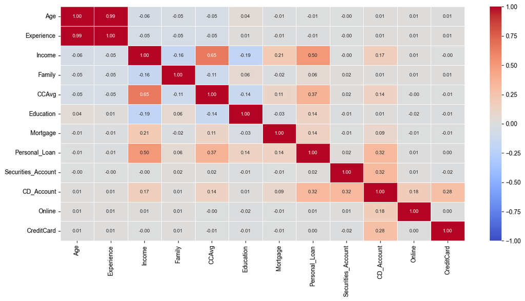

```python
# Plot the correlation matrix as a heatmap.
plt.figure(figsize=(15, 7))
sns.heatmap(personal_loan_df.corr(), annot=True, vmin=-1, vmax=1, fmt='.2f', cmap='coolwarm', linewidths=0.5)
plt.show()
```

```python
# Dropping Experience as it is perfectly correlated with Age, 0.99
X = personal_loan_df.drop(['Personal_Loan', 'Experience'], axis=1)
Y = personal_loan_df['Personal_Loan']

X = pd.get_dummies(X, columns=['ZIPCode', 'Education'], drop_first=True)

# Splitting data in train and test sets
X_train, X_test, y_train, y_test = train_test_split(
    X, Y, test_size=0.30, random_state=1
)
```

```python
# Print the shape of the training set.
print('Shape of Training set : ', X_train.shape)

# Print the shape of the test set.
print('Shape of test set : ', X_test.shape)

# Print a blank line for better readability.
print()

# Print the percentage distribution of classes in the training set.
print('Percentage of classes in training set:')
print(y_train.value_counts(normalize=True).to_dict())

# Print a blank line for better readability.
print()

# Print the percentage distribution of classes in the test set.
print('Percentage of classes in test set:')
print(y_test.value_counts(normalize=True).to_dict())
```

```
Shape of Training set :  (3500, 478)
Shape of test set :  (1500, 478)

Percentage of classes in training set:
{0: 0.9054285714285715, 1: 0.09457142857142857}

Percentage of classes in test set:
{0: 0.9006666666666666, 1: 0.09933333333333333}
```

```python
# Feature engineering

# Change categorical features to 'category'.
category_cols = [
    'Education',
    'Personal_Loan',
    'Securities_Account',
    'CD_Account',
    'Online',
    'CreditCard',
    'ZIPCode',
]
personal_loan_df[category_cols] = personal_loan_df[category_cols].astype('category')

# Check for changes in the data types.
categorical_columns = personal_loan_df.select_dtypes(include=['category']).columns.tolist()

# Print the categorical columns.
print('Categorical columns:', categorical_columns)
```

```
Categorical columns: ['ZIPCode', 'Education', 'Personal_Loan', 'Securities_Account', 'CD_Account', 'Online', 'CreditCard', 'AgeGroup']
```

## Model Building

```python
# Encode categorical variables using one-hot encoding.
X_train_encoded = pd.get_dummies(X_train)
X_test_encoded = pd.get_dummies(X_test)

# Ensure the training and test sets have the same columns after encoding.
X_train_encoded, X_test_encoded = X_train_encoded.align(X_test_encoded, join='left', axis=1, fill_value=0)

# Initialize the DecisionTreeClassifier with the Gini impurity criterion and a fixed random state.
model = DecisionTreeClassifier(
    criterion="gini",
    random_state=1,
    # max_depth=5,            # Limit the maximum depth of the tree
    # min_samples_split=10,   # Minimum number of samples required to split an internal node
    # min_samples_leaf=5,     # Minimum number of samples required to be at a leaf node
    # max_leaf_nodes=20       # Maximum number of leaf nodes
)

# Fit the model on the encoded training data.
model.fit(X_train_encoded, y_train)
```

```
DecisionTreeClassifier(random_state=1)
```

```
Accuracy: 1.00
Precision: 1.00
Recall: 1.00
F1 Score: 1.00
Classification Report:
              precision    recall  f1-score   support

           0       1.00      1.00      1.00      3169
           1       1.00      1.00      1.00       331

    accuracy                           1.00      3500
   macro avg       1.00      1.00      1.00      3500
weighted avg       1.00      1.00      1.00      3500
```

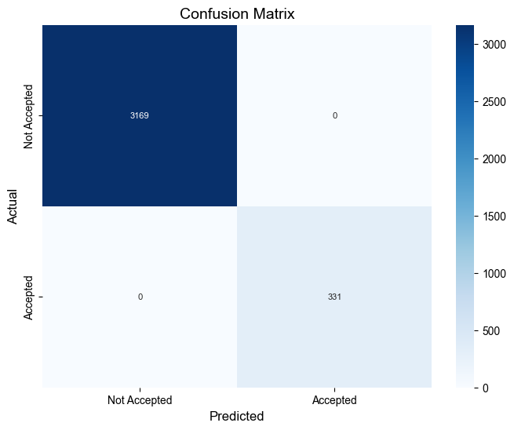

```python
# Predict on the training data.
y_train_pred = model.predict(X_train_encoded)

# Calculate accuracy.
accuracy = accuracy_score(y_train, y_train_pred)
print(f'Accuracy: {accuracy:.2f}')

# Calculate precision.
precision = precision_score(y_train, y_train_pred)
print(f'Precision: {precision:.2f}')

# Calculate recall.
recall = recall_score(y_train, y_train_pred)
print(f'Recall: {recall:.2f}')

# Calculate F1 score.
f1 = f1_score(y_train, y_train_pred)
print(f'F1 Score: {f1:.2f}')

# Print classification report.
print('Classification Report:')
print(classification_report(y_train, y_train_pred))

# Calculate confusion matrix.
conf_matrix = confusion_matrix(y_train, y_train_pred)

# Plot confusion matrix.
plt.figure(figsize=(8, 6))
sns.heatmap(conf_matrix, annot=True, fmt='d', cmap='Blues', xticklabels=['Not Accepted', 'Accepted'], yticklabels=['Not Accepted', 'Accepted'])
plt.xlabel('Predicted')
plt.ylabel('Actual')
plt.title('Confusion Matrix')
plt.show()
```

```python
# Function for model performance evaluation.

def model_performance_classification_sklearn(model, X, y):
    # Predict the labels for the input features X using the provided model.
    y_pred = model.predict(X)

    # Calculate the accuracy of the model.
    accuracy = accuracy_score(y, y_pred)

    # Calculate the precision of the model.
    precision = precision_score(y, y_pred)

    # Calculate the recall of the model.
    recall = recall_score(y, y_pred)

    # Calculate the F1 score of the model.
    f1 = f1_score(y, y_pred)

    # Return a dictionary containing the performance metrics.
    return {'Accuracy': accuracy, 'Precision': precision, 'Recall': recall, 'F1 Score': f1}
```

```python
# Check performance on training data.
decision_tree_perf_train = model_performance_classification_sklearn(
    model, X_train_encoded, y_train
)
decision_tree_perf_train
```

```
{'Accuracy': 1.0, 'Precision': 1.0, 'Recall': 1.0, 'F1 Score': 1.0}
```

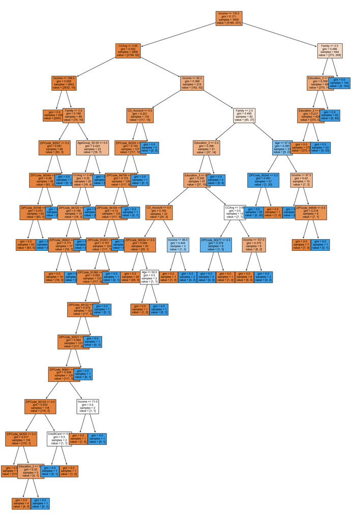

```python
# Visualize the decision tree.
plt.figure(figsize=(20, 30))
out = tree.plot_tree(
    model, # type: ignore
    feature_names=list(X_train_encoded.columns),  # type: ignore
    filled=True,
    fontsize=9,
    node_ids=False,
    class_names=None,
)
# Add arrows to the decision tree split if they are missing.
for o in out:
    arrow = o.arrow_patch
    if arrow is not None:
        arrow.set_edgecolor('black')
        arrow.set_linewidth(1)
plt.show()
```

```python
# Generate a text report showing the rules of the decision tree.
tree_rules = tree.export_text(model, feature_names=list(X_train_encoded.columns), show_weights=True) # type: ignore
print(tree_rules)
```

```
|--- Income <= 116.50
|   |--- CCAvg <= 2.95
|   |   |--- Income <= 106.50
|   |   |   |--- weights: [2553.00, 0.00] class: 0
|   |   |--- Income >  106.50
|   |   |   |--- Family <= 3.50
|   |   |   |   |--- ZIPCode_92007 <= 0.50
|   |   |   |   |   |--- ZIPCode_90049 <= 0.50
|   |   |   |   |   |   |--- ZIPCode_93106 <= 0.50
|   |   |   |   |   |   |   |--- weights: [63.00, 0.00] class: 0
|   |   |   |   |   |   |--- ZIPCode_93106 >  0.50
|   |   |   |   |   |   |   |--- weights: [0.00, 1.00] class: 1
|   |   |   |   |   |--- ZIPCode_90049 >  0.50
|   |   |   |   |   |   |--- weights: [0.00, 1.00] class: 1
|   |   |   |   |--- ZIPCode_92007 >  0.50
|   |   |   |   |   |--- weights: [0.00, 1.00] class: 1
|   |   |   |--- Family >  3.50
|   |   |   |   |--- AgeGroup_50-59 <= 0.50
|   |   |   |   |   |--- CCAvg <= 2.45
|   |   |   |   |   |   |--- ZIPCode_94720 <= 0.50
|   |   |   |   |   |   |   |--- ZIPCode_95822 <= 0.50
|   |   |   |   |   |   |   |   |--- weights: [16.00, 0.00] class: 0
|   |   |   |   |   |   |   |--- ZIPCode_95822 >  0.50
|   |   |   |   |   |   |   |   |--- weights: [0.00, 1.00] class: 1
|   |   |   |   |   |   |--- ZIPCode_94720 >  0.50
|   |   |   |   |   |   |   |--- weights: [0.00, 1.00] class: 1
|   |   |   |   |   |--- CCAvg >  2.45
|   |   |   |   |   |   |--- weights: [0.00, 2.00] class: 1
|   |   |   |   |--- AgeGroup_50-59 >  0.50
|   |   |   |   |   |--- weights: [0.00, 3.00] class: 1
|   |--- CCAvg >  2.95
|   |   |--- Income <= 92.50
|   |   |   |--- CD_Account <= 0.50
|   |   |   |   |--- ZIPCode_92220 <= 0.50
|   |   |   |   |   |--- ZIPCode_94709 <= 0.50
|   |   |   |   |   |   |--- ZIPCode_94105 <= 0.50
|   |   |   |   |   |   |   |--- ZIPCode_91203 <= 0.50
|   |   |   |   |   |   |   |   |--- ZIPCode_91360 <= 0.50
|   |   |   |   |   |   |   |   |   |--- ZIPCode_94122 <= 0.50
|   |   |   |   |   |   |   |   |   |   |--- ZIPCode_92521 <= 0.50
```

[output cut: 57 more lines]

```
|   |   |   |   |   |   |--- ZIPCode_94606 <= 0.50
|   |   |   |   |   |   |   |--- weights: [7.00, 0.00] class: 0
|   |   |   |   |   |   |--- ZIPCode_94606 >  0.50
|   |   |   |   |   |   |   |--- weights: [0.00, 1.00] class: 1
|--- Income >  116.50
|   |--- Family <= 2.50
|   |   |--- Education_3 <= 0.50
|   |   |   |--- Education_2 <= 0.50
|   |   |   |   |--- weights: [375.00, 0.00] class: 0
|   |   |   |--- Education_2 >  0.50
|   |   |   |   |--- weights: [0.00, 53.00] class: 1
|   |   |--- Education_3 >  0.50
|   |   |   |--- weights: [0.00, 62.00] class: 1
|   |--- Family >  2.50
|   |   |--- weights: [0.00, 154.00] class: 1
```

```python
# Assign the feature importances to a variable.
importances = model.feature_importances_

# Sort indices in descending order.
indices = np.argsort(importances)[::-1]

# Create a DataFrame for feature importances.
feature_importances_df = pd.DataFrame({
    'Feature': [list(X_train_encoded.columns)[i] for i in indices],  # type: ignore
    'Importance': importances[indices]
})

# Print the DataFrame.
print(feature_importances_df)
```

```
           Feature  Importance
0           Income    0.310801
1           Family    0.246862
2      Education_2    0.165238
3      Education_3    0.144207
4            CCAvg    0.046435
..             ...         ...
477  ZIPCode_94302    0.000000
478  ZIPCode_94303    0.000000
479  ZIPCode_94304    0.000000
480  ZIPCode_94306    0.000000
481  ZIPCode_93014    0.000000

[482 rows x 2 columns]
```

```
Accuracy: 0.98
Precision: 0.96
Recall: 0.87
F1 Score: 0.91
Classification Report:
              precision    recall  f1-score   support

           0       0.99      1.00      0.99      1351
           1       0.96      0.87      0.91       149

    accuracy                           0.98      1500
   macro avg       0.97      0.93      0.95      1500
weighted avg       0.98      0.98      0.98      1500
```

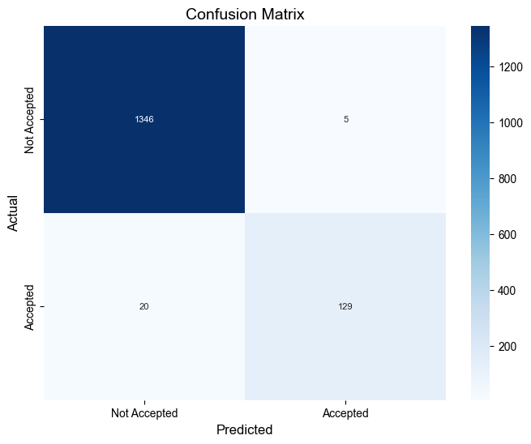

```python
# Check model performance on the test data.

# Predict on the test data.
y_test_pred = model.predict(X_test_encoded) # type: ignore

# Calculate accuracy.
accuracy = accuracy_score(y_test, y_test_pred)
print(f'Accuracy: {accuracy:.2f}')

# Calculate precision.
precision = precision_score(y_test, y_test_pred)
print(f'Precision: {precision:.2f}')

# Calculate recall.
recall = recall_score(y_test, y_test_pred)
print(f'Recall: {recall:.2f}')

# Calculate F1 score.
f1 = f1_score(y_test, y_test_pred)
print(f'F1 Score: {f1:.2f}')

# Print classification report.
print('Classification Report:')
print(classification_report(y_test, y_test_pred))

# Calculate confusion matrix
conf_matrix = confusion_matrix(y_test, y_test_pred)

# Plot confusion matrix
plt.figure(figsize=(8, 6))
sns.heatmap(conf_matrix, annot=True, fmt='d', cmap='Blues', xticklabels=['Not Accepted', 'Accepted'], yticklabels=['Not Accepted', 'Accepted'])
plt.xlabel('Predicted')
plt.ylabel('Actual')
plt.title('Confusion Matrix')
plt.show()
```

```python
# Check performance on the test data.
decision_tree_perf_test = model_performance_classification_sklearn(model, X_test_encoded, y_test) # type: ignore
decision_tree_perf_test
```

```
{'Accuracy': 0.9833333333333333,
 'Precision': 0.9626865671641791,
 'Recall': 0.8657718120805369,
 'F1 Score': 0.9116607773851589}
```

### Pre-Pruning

```python
# Choose the type of classifier.
estimator = DecisionTreeClassifier(random_state=1)

# Hyperparameter grid.
parameters = {
    "max_depth": np.arange(6, 15),
    "min_samples_leaf": [1, 2, 5, 7, 10],
    "max_leaf_nodes": [2, 3, 5, 10],
}

# Type of scoring used to compare parameter combinations.
acc_scorer = make_scorer(recall_score)

# Run the grid search.
grid_obj = GridSearchCV(estimator, parameters, scoring=acc_scorer, cv=5)
grid_obj = grid_obj.fit(X_train_encoded, y_train) # type: ignore

# Set the clf to the best combination of parameters.
estimator = grid_obj.best_estimator_

# Fit the best algorithm to the data.
estimator.fit(X_train_encoded, y_train) # type: ignore
```

```
DecisionTreeClassifier(max_depth=6, max_leaf_nodes=10, min_samples_leaf=10,
                       random_state=1)
```

```
Accuracy: 1.00
Precision: 1.00
Recall: 1.00
F1 Score: 1.00
Classification Report:
              precision    recall  f1-score   support

           0       1.00      1.00      1.00      3169
           1       1.00      1.00      1.00       331

    accuracy                           1.00      3500
   macro avg       1.00      1.00      1.00      3500
weighted avg       1.00      1.00      1.00      3500
```

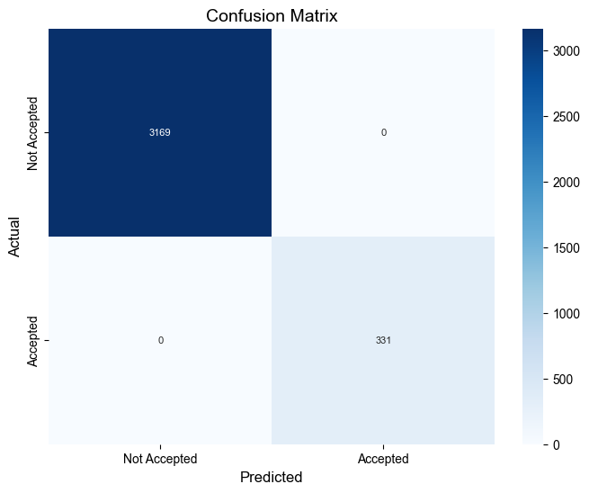

```python
# Check model performance on the test data.

# Predict on the test data.
y_test_pred = model.predict(X_train_encoded) # type: ignore

# Calculate accuracy.
accuracy = accuracy_score(y_train, y_train_pred) # type: ignore
print(f'Accuracy: {accuracy:.2f}')

# Calculate precision.
precision = precision_score(y_train, y_train_pred) # type: ignore
print(f'Precision: {precision:.2f}')

# Calculate recall.
recall = recall_score(y_train, y_train_pred) # type: ignore
print(f'Recall: {recall:.2f}')

# Calculate F1 score.
f1 = f1_score(y_train, y_train_pred) # type: ignore
print(f'F1 Score: {f1:.2f}')

# Print classification report.
print('Classification Report:')
print(classification_report(y_train, y_train_pred)) # type: ignore

# Calculate confusion matrix.
conf_matrix = confusion_matrix(y_train, y_train_pred) # type: ignore

# Plot confusion matrix.
plt.figure(figsize=(8, 6))
sns.heatmap(conf_matrix, annot=True, fmt='d', cmap='Blues', xticklabels=['Not Accepted', 'Accepted'], yticklabels=['Not Accepted', 'Accepted'])
plt.xlabel('Predicted')
plt.ylabel('Actual')
plt.title('Confusion Matrix')
plt.show()
```

```python
# Check performance on the tuned data.
decision_tree_tune_perf_train = model_performance_classification_sklearn(estimator, X_train_encoded, y_train) # type: ignore
decision_tree_tune_perf_train
```

```
{'Accuracy': 0.9877142857142858,
 'Precision': 0.996551724137931,
 'Recall': 0.8731117824773413,
 'F1 Score': 0.9307568438003219}
```

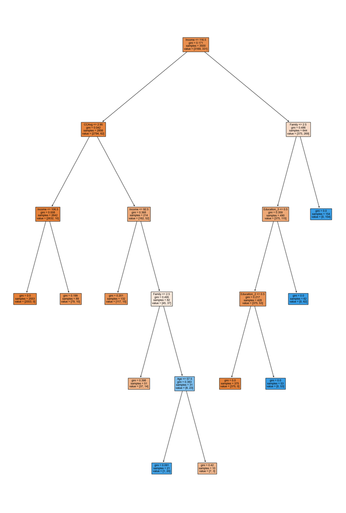

```python
# Visualize the decision tree.
plt.figure(figsize=(20, 30))
out = tree.plot_tree(
    estimator,
    feature_names=list(X_train_encoded.columns), # type: ignore
    filled=True,
    fontsize=9,
    node_ids=False,
    class_names=None,
)
# Add arrows to the decision tree split if they are missing.
for o in out:
    arrow = o.arrow_patch
    if arrow is not None:
        arrow.set_edgecolor("black")
        arrow.set_linewidth(1)
plt.show()
```

```
Accuracy: 0.99
Precision: 1.00
Recall: 0.87
F1 Score: 0.93
Classification Report:
              precision    recall  f1-score   support

           0       0.99      1.00      0.99      3169
           1       1.00      0.87      0.93       331

    accuracy                           0.99      3500
   macro avg       0.99      0.94      0.96      3500
weighted avg       0.99      0.99      0.99      3500
```

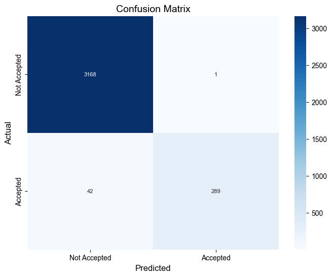

```python
# Predict on the training data.
y_train_pred = estimator.predict(X_train_encoded) # type: ignore

# Calculate accuracy.
accuracy = accuracy_score(y_train, y_train_pred)
print(f'Accuracy: {accuracy:.2f}')

# Calculate precision.
precision = precision_score(y_train, y_train_pred)
print(f'Precision: {precision:.2f}')

# Calculate recall.
recall = recall_score(y_train, y_train_pred)
print(f'Recall: {recall:.2f}')

# Calculate F1 score.
f1 = f1_score(y_train, y_train_pred)
print(f'F1 Score: {f1:.2f}')

# Print classification report.
print('Classification Report:')
print(classification_report(y_train, y_train_pred))

# Calculate confusion matrix.
conf_matrix = confusion_matrix(y_train, y_train_pred)

# Plot confusion matrix.
plt.figure(figsize=(8, 6))
sns.heatmap(conf_matrix, annot=True, fmt='d', cmap='Blues', xticklabels=['Not Accepted', 'Accepted'], yticklabels=['Not Accepted', 'Accepted'])
plt.xlabel('Predicted')
plt.ylabel('Actual')
plt.title('Confusion Matrix')
plt.show()
```

```python
# Generate a text report showing the rules of the decision tree.
tree_rules = tree.export_text(estimator, feature_names=list(X_train_encoded.columns), show_weights=True) # type: ignore
print(tree_rules)
```

```
|--- Income <= 116.50
|   |--- CCAvg <= 2.95
|   |   |--- Income <= 106.50
|   |   |   |--- weights: [2553.00, 0.00] class: 0
|   |   |--- Income >  106.50
|   |   |   |--- weights: [79.00, 10.00] class: 0
|   |--- CCAvg >  2.95
|   |   |--- Income <= 92.50
|   |   |   |--- weights: [117.00, 15.00] class: 0
|   |   |--- Income >  92.50
|   |   |   |--- Family <= 2.50
|   |   |   |   |--- weights: [37.00, 14.00] class: 0
|   |   |   |--- Family >  2.50
|   |   |   |   |--- Age <= 57.50
|   |   |   |   |   |--- weights: [1.00, 20.00] class: 1
|   |   |   |   |--- Age >  57.50
|   |   |   |   |   |--- weights: [7.00, 3.00] class: 0
|--- Income >  116.50
|   |--- Family <= 2.50
|   |   |--- Education_3 <= 0.50
|   |   |   |--- Education_2 <= 0.50
|   |   |   |   |--- weights: [375.00, 0.00] class: 0
|   |   |   |--- Education_2 >  0.50
|   |   |   |   |--- weights: [0.00, 53.00] class: 1
|   |   |--- Education_3 >  0.50
|   |   |   |--- weights: [0.00, 62.00] class: 1
|   |--- Family >  2.50
|   |   |--- weights: [0.00, 154.00] class: 1
```

```python
# Check performance on the test data.
decision_tree_tune_perf_test = model_performance_classification_sklearn(model, X_test_encoded, y_test)
decision_tree_tune_perf_test
```

```
{'Accuracy': 0.9833333333333333,
 'Precision': 0.9626865671641791,
 'Recall': 0.8657718120805369,
 'F1 Score': 0.9116607773851589}
```

```python
# Compute the pruning path for the decision tree using minimal cost-complexity pruning.
clf = DecisionTreeClassifier(random_state=1)
path = clf.cost_complexity_pruning_path(X_train_encoded, y_train) # type: ignore
ccp_alphas, impurities = path.ccp_alphas, path.impurities

# Create a DataFrame and sort by ccp_alphas in descending order.
pruning_path_df = pd.DataFrame(path)
pruning_path_df_sorted = pruning_path_df.sort_values(by='ccp_alphas', ascending=False)

# Show sorted pruning path values.
pruning_path_df_sorted
```

|  | ccp_alphas | impurities |
| --- | --- | --- |
| 23 | 0.047088 | 0.171255 |
| 22 | 0.039216 | 0.124167 |
| 21 | 0.025146 | 0.084951 |
| 20 | 0.006473 | 0.034659 |
| 19 | 0.003294 | 0.028187 |
| 18 | 0.002407 | 0.024893 |
| 17 | 0.002333 | 0.022486 |
| 16 | 0.001647 | 0.020153 |
| 15 | 0.001305 | 0.018505 |
| 14 | 0.000940 | 0.017200 |
| 13 | 0.000762 | 0.016260 |
| 12 | 0.000760 | 0.014736 |
| 11 | 0.000700 | 0.011695 |
| 10 | 0.000625 | 0.010995 |
| 9 | 0.000545 | 0.010370 |
| 8 | 0.000544 | 0.008734 |
| 7 | 0.000513 | 0.008190 |
| 6 | 0.000508 | 0.004597 |
| 5 | 0.000500 | 0.003581 |
| 4 | 0.000476 | 0.003081 |
| 3 | 0.000381 | 0.002605 |
| 2 | 0.000279 | 0.002224 |
| 1 | 0.000276 | 0.000552 |
| 0 | 0.000000 | 0.000000 |

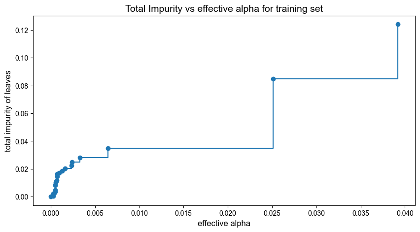

```python
# Create a figure and an axis object with a specified size.
fig, ax = plt.subplots(figsize=(10, 5))

# Plot the relationship between effective alpha and total impurity of leaves
# Use markers "o" and draw style "steps-post" for the plot.
ax.plot(ccp_alphas[:-1], impurities[:-1], marker="o", drawstyle="steps-post")

# Set the label for the x-axis.
ax.set_xlabel("effective alpha")

# Set the label for the y-axis.
ax.set_ylabel("total impurity of leaves")

# Set the title of the plot.
ax.set_title("Total Impurity vs effective alpha for training set")

# Display the plot.
plt.show()
```

```python
# Initialize an empty list to store the decision tree classifiers.
clfs = []

# Iterate over the list of ccp_alpha values.
for ccp_alpha in ccp_alphas:
    # Initialize a DecisionTreeClassifier with the current ccp_alpha value
    # and a fixed random state.
    clf = DecisionTreeClassifier(random_state=1, ccp_alpha=ccp_alpha)

    # Fit the decision tree classifier on the training data.
    clf.fit(X_train_encoded, y_train) # type: ignore

    # Append the fitted classifier to the list.
    clfs.append(clf)

# Print the number of nodes in the last tree and the corresponding ccp_alpha value.
print(
    "Number of nodes in the last tree is: {} with ccp_alpha: {}".format(
        clfs[-1].tree_.node_count, ccp_alphas[-1]
    )
)
```

```
Number of nodes in the last tree is: 1 with ccp_alpha: 0.04708834100596766
```

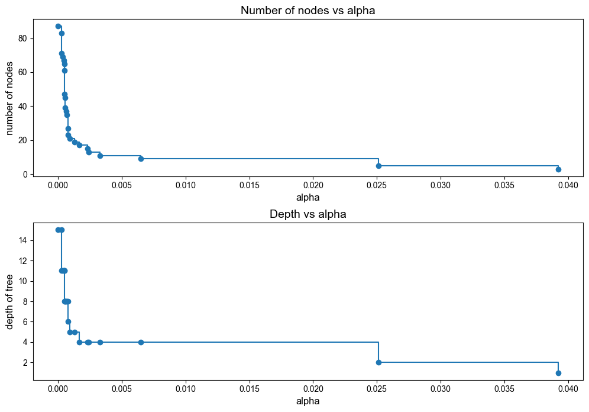

```python
# Remove the last element from the list of classifiers and ccp_alphas.
clfs = clfs[:-1]
ccp_alphas = ccp_alphas[:-1]

# Calculate the number of nodes for each classifier.
node_counts = [clf.tree_.node_count for clf in clfs]

# Calculate the depth of each classifier.
depth = [clf.tree_.max_depth for clf in clfs]

# Create a figure with two subplots, arranged vertically, with a specified size.
fig, ax = plt.subplots(2, 1, figsize=(10, 7))

# Plot the number of nodes vs alpha on the first subplot.
ax[0].plot(ccp_alphas, node_counts, marker="o", drawstyle="steps-post")
ax[0].set_xlabel("alpha")
ax[0].set_ylabel("number of nodes")
ax[0].set_title("Number of nodes vs alpha")

# Plot the depth of the tree vs alpha on the second subplot.
ax[1].plot(ccp_alphas, depth, marker="o", drawstyle="steps-post")
ax[1].set_xlabel("alpha")
ax[1].set_ylabel("depth of tree")
ax[1].set_title("Depth vs alpha")

# Adjust the layout to prevent overlap.
fig.tight_layout()
```

```python
# Initialize an empty list to store recall scores for the training set.
recall_train = []

# Iterate over the list of classifiers.
for clf in clfs:
    # Predict the labels for the training set using the current classifier.
    pred_train = clf.predict(X_train_encoded)

    # Calculate the recall score for the training set.
    values_train = recall_score(y_train, pred_train)

    # Append the recall score to the recall_train list.
    recall_train.append(values_train)

# Initialize an empty list to store recall scores for the test set.
recall_test = []

# Iterate over the list of classifiers.
for clf in clfs:
    # Predict the labels for the test set using the current classifier.
    pred_test = clf.predict(X_test_encoded) # type: ignore

    # Calculate the recall score for the test set.
    values_test = recall_score(y_test, pred_test)

    # Append the recall score to the recall_test list.
    recall_test.append(values_test)
```

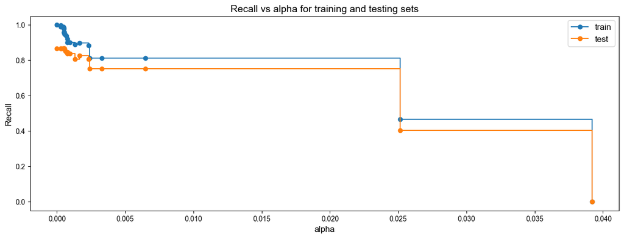

```python
# Create a figure and an axis object with a specified size.
fig, ax = plt.subplots(figsize=(15, 5))

# Set the label for the x-axis.
ax.set_xlabel("alpha")

# Set the label for the y-axis.
ax.set_ylabel("Recall")

# Set the title of the plot.
ax.set_title("Recall vs alpha for training and testing sets")

# Plot the recall scores for the training set vs alpha.
# Use markers "o" and draw style "steps-post" for the plot.
ax.plot(ccp_alphas, recall_train, marker="o", label="train", drawstyle="steps-post")

# Plot the recall scores for the test set vs alpha.
# Use markers "o" and draw style "steps-post" for the plot.
ax.plot(ccp_alphas, recall_test, marker="o", label="test", drawstyle="steps-post")

# Add a legend to the plot.
ax.legend()

# Display the plot.
plt.show()
```

```python
# Find the index of the classifier with the highest recall score on the test set.
index_best_model = np.argmax(recall_test)

# Select the classifier corresponding to the best recall score.
best_model = clfs[index_best_model]

# Print the details of the best model.
print(best_model)
```

```
DecisionTreeClassifier(random_state=1)
```

### Post-Pruning

```python
# Initialize the DecisionTreeClassifier with the last ccp_alpha value from the pruning path,
# set class weights to handle class imbalance, and set a random state for reproducibility.
estimator_2 = DecisionTreeClassifier(
    ccp_alpha=ccp_alphas[-1],  # Use the last ccp_alpha value.
    class_weight={0: 0.15, 1: 0.85},  # Set class weights.
    random_state=1  # Set random state for reproducibility.
)

# Fit the classifier on the training data.
estimator_2.fit(X_train_encoded, y_train) # type: ignore
```

```
DecisionTreeClassifier(ccp_alpha=0.03921599695778932,
                       class_weight={0: 0.15, 1: 0.85}, random_state=1)
```

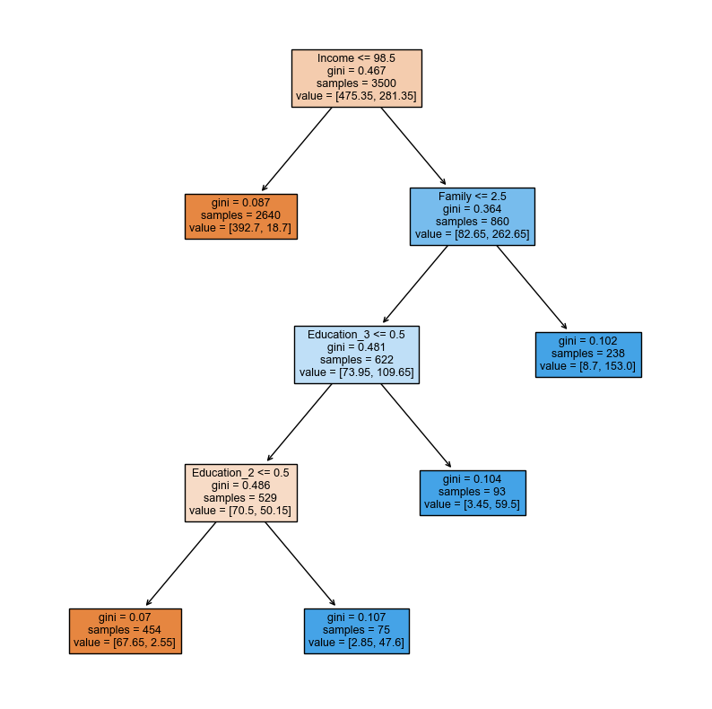

```python
# Visualize the decision tree.
plt.figure(figsize=(10, 10))
out = tree.plot_tree(
    estimator_2,
    feature_names=list(X_train_encoded.columns), # type: ignore
    filled=True,
    fontsize=9,
    node_ids=False,
    class_names=None,
)
# Add arrows to the decision tree split if they are missing.
for o in out:
    arrow = o.arrow_patch
    if arrow is not None:
        arrow.set_edgecolor('black')
        arrow.set_linewidth(1)
plt.show()
```

```python
# Generate a text report showing the rules of the decision tree.
tree_rules = tree.export_text(estimator_2, feature_names=list(X_train_encoded.columns),show_weights=True) # type: ignore
print(tree_rules)
```

```
|--- Income <= 98.50
|   |--- weights: [392.70, 18.70] class: 0
|--- Income >  98.50
|   |--- Family <= 2.50
|   |   |--- Education_3 <= 0.50
|   |   |   |--- Education_2 <= 0.50
|   |   |   |   |--- weights: [67.65, 2.55] class: 0
|   |   |   |--- Education_2 >  0.50
|   |   |   |   |--- weights: [2.85, 47.60] class: 1
|   |   |--- Education_3 >  0.50
|   |   |   |--- weights: [3.45, 59.50] class: 1
|   |--- Family >  2.50
|   |   |--- weights: [8.70, 153.00] class: 1
```

```python
# Check performance on the test data.
decision_tree_tune_post_train = model_performance_classification_sklearn(model, X_train_encoded, y_train) # type: ignore
decision_tree_tune_post_train
```

```
{'Accuracy': 1.0, 'Precision': 1.0, 'Recall': 1.0, 'F1 Score': 1.0}
```

```python
# Assign the feature importances to a variable.
importances = estimator_2.feature_importances_

# Sort indices in descending order.
indices = np.argsort(importances)[::-1]

# Create a DataFrame for feature importances.
feature_importances_df = pd.DataFrame({
    'Feature': [list(X_train_encoded.columns)[i] for i in indices], # type: ignore
    'Importance': importances[indices]
})

# Print the DataFrame.
print(feature_importances_df)
```

```
            Feature  Importance
0            Income    0.675027
1       Education_2    0.169826
2       Education_3    0.081541
3            Family    0.073607
4    AgeGroup_60-69    0.000000
..              ...         ...
477   ZIPCode_94305    0.000000
478   ZIPCode_94306    0.000000
479   ZIPCode_94309    0.000000
480   ZIPCode_94402    0.000000
481             Age    0.000000

[482 rows x 2 columns]
```

```python
# Check performance on the training data.
decision_tree_tune_post_train = model_performance_classification_sklearn(estimator_2, X_train_encoded, y_train) # type: ignore
decision_tree_tune_post_train
```

```
{'Accuracy': 0.9642857142857143,
 'Precision': 0.7536945812807881,
 'Recall': 0.9244712990936556,
 'F1 Score': 0.8303934871099049}
```

## Model Comparison and Final Model Selection

```python
# Training data performance comparison.

# Convert dictionaries to DataFrames
decision_tree_perf_train_df = pd.DataFrame.from_dict(decision_tree_perf_train, orient='index') # type: ignore
decision_tree_tune_perf_train_df = pd.DataFrame.from_dict(decision_tree_tune_perf_train, orient='index')

# Concatenate the performance DataFrames along the columns
models_train_comp_df = pd.concat(
    [decision_tree_perf_train_df, decision_tree_tune_perf_train_df], axis=1
)

# Set the column names for the concatenated DataFrame
models_train_comp_df.columns = ["Decision Tree sklearn", "Decision Tree (Pre-Pruning)"]

# Print the training performance comparison
print("Training performance comparison:")
models_train_comp_df
```

```
Training performance comparison:
```

|  | Decision Tree sklearn | Decision Tree (Pre-Pruning) |
| --- | --- | --- |
| Accuracy | 1.0 | 0.987714 |
| Precision | 1.0 | 0.996552 |
| Recall | 1.0 | 0.873112 |
| F1 Score | 1.0 | 0.930757 |

```python
# Test data performance comparison.

# Convert dictionaries to DataFrames
decision_tree_perf_test_df = pd.DataFrame.from_dict(decision_tree_perf_test, orient='index')
decision_tree_tune_post_test_df = pd.DataFrame.from_dict(decision_tree_tune_post_train, orient='index')

# Concatenate the performance DataFrames along the columns
models_train_comp_df = pd.concat(
    [decision_tree_perf_test_df, decision_tree_tune_post_test_df], axis=1
)

# Set the column names for the concatenated DataFrame
models_train_comp_df.columns = ["Decision Tree sklearn", "Decision Tree (Post-Pruning)"]

# Print the training performance comparison
print("Test performance comparison:")
models_train_comp_df
```

```
Test performance comparison:
```

[output not shown]

## Actionable Insights and Business Recommendations

### **Model Insights**

The pre‑pruning model demonstrates stronger overall accuracy (0.9877) compared to the post‑pruning model (0.9643). Precision is also higher in the pre‑pruning case (0.9966), though recall is somewhat lower (0.8731 versus 0.9245). Considering accuracy, precision, and F1 score, the pre‑pruning approach is the recommended option. However, if recall is prioritized for instance, in scenarios where capturing more true positives is critical the post‑pruning model may be preferable despite its reduced precision.

### **Recommendations**

1. **Data Overall**: *Gather more information to understand why loan offers are declined for instance, whether applicants have prior defaults with other banks.
   - Collect customer satisfaction feedback across services such as online banking, CDs, securities, and credit card accounts.
   - Track payment behavior to identify missed installments, which can guide whether offers should be tailored to individuals or broader groups.
   - Record customer tenure to assess loyalty and its influence on loan acceptance.
2. **Feature Importance**:
   - Explore additional variables that could strengthen business strategies. For example, if demographics prove to be strong predictors, marketing campaigns or service offerings can be customized accordingly.
3. **Customer Segmentation**:
   - Examine ZIP code patterns to design localized campaigns or premium programs for high‑value services like loans and credit cards. Larger loan amounts could be targeted toward higher‑income segments.
   - For lower‑income customers, consider offering smaller loans at reduced interest rates to encourage adoption of personal loans.
4. **Loyalty**:
   - Develop loyalty initiatives that provide better interest rates and reduced service fees to reward long‑term customers.
5. **Business Processes**:
   - Implement automation in parts of the loan approval workflow to reduce manual effort, speed up processing, and improve customer satisfaction.
   - As part of automation, apply stricter credit checks or adjust loan sizes to mitigate risk, using income and credit card data as key inputs.
   - Continuously track model performance and refresh it with new data to maintain accuracy and relevance over time.

```python
!jupyter nbconvert --to html "SmitrajRaut_Personal_Loan_Full_Code_Notebook.ipynb"
```

[output not shown]